# Predictions on Movie Ratings

André Jakob

12/06/2019

## Introduction

This exercise is also know as the Netflix challange, where the users of a movie platform rates movies using a five stars scale. The purpose of the exercise is to write a Machine Learning algorithim that predicts the potential rating by users that had obviously not seen all the movies available, from the given ratings dataset.

## Method

In this chapter I describe the step of the work done. We started from the movielens dataset available in kagle, which has an enormous dimmension of 10,000,054 observations. After some previous analysis on the data to know how it was structured, we followed the lessons of the previous EdX courses, which teached that are some steps to be done to acchieve a good prediction from a great data set as these. First we defined a sample index with 10% of the size of the original data set. This sample was divided between test and training set. Below we see how many users and movies the training set has.

```r
k1<-edx %>%
  summarize(n_users = n_distinct(userId),
            n_movies = n_distinct(movieId))
kable(k1)
```

| n_users | n_movies |
| --- | --- |
| 69878 | 10677 |

By the way, an important background to this exercise is to know that each user can rate the movies from 0.5 to 5, in 0.5 intervals. Even so, we see in the graphic below that a fractional rating is more rare than a rounded one.

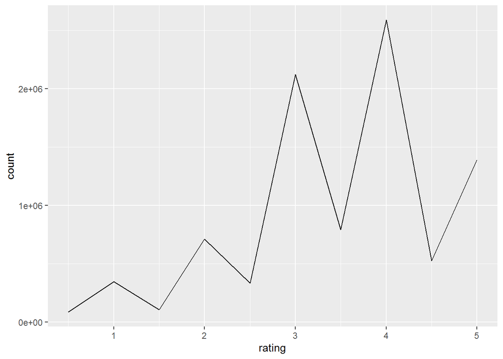

```r
edx %>%
  group_by(rating) %>%
  summarize(count = n()) %>%
  ggplot(aes(x = rating, y = count)) +
  geom_line()
```

The training set was used to train an algorithm and respectively predictions. So those predictions were applied in the test set. The general idea was to start with the simplest possible prediction, and then adding complexions. Each improvement went along with the measurement of its Root-mean-square deviation - a measurement analog as the standard deviation. The simplest possible prediction is just the average, regardless of the users and movies. As expected,we had a too high RMSE for about to one, which is obviously not enough, since the possible ratings go from 0.5 to 5. Using just the average to predict the ratings, regardless of the criteria, is almost good enough as guessing blindly. The next step is then add our first bias: the movies. First we used the least squares method to estimate this bias. Since the whole data-set is enormous, we therefore estimated this value from our train data set. With one bias the prediction was a little better, not good enough though. So we added another bias for users. Each user rates the movies according to their own criteria. Some users tend to give better ratings while others are more rigorous. Below I show a histogram for the average of stars each user gives. There is a substantial variability among them.

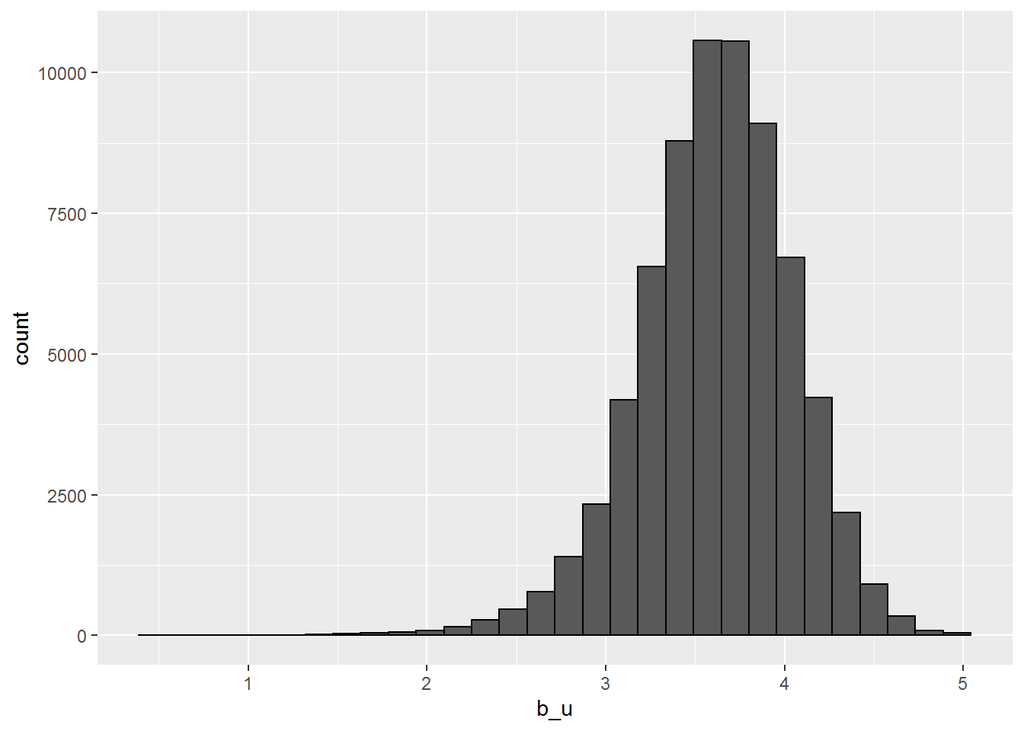

```r
edx %>%
  group_by(userId) %>%
  summarize(b_u = mean(rating)) %>%
  filter(n()>=100) %>%
  ggplot(aes(b_u)) +
  geom_histogram(bins = 30, color = "black")
```

For the same reason said above, we could not run a prediction for the whole data set, so we estimated the bias from the training set instead and ran the prediction, achieving a prediction up to 0.865. Even so, we took a look at the greatest mistakes to learn what could be done to make the algorithm even better. We learned that some obscure movies can mess the prediction. So we saw the top and worse 10 movies according to the prediction and how often they were rated. Below both tables.

```r
k2<-movie_avgs %>% left_join(movie_titles, by="movieId") %>%
  arrange(desc(b_i)) %>%
  select(title, b_i) %>%
  slice(1:10)
kable(k2)
```

| title | b_i |
| --- | --- |
| Hellhounds on My Trail (1999) | 1.487536 |
| Satan’s Tango (Sátántangó) (1994) | 1.487536 |
| Shadows of Forgotten Ancestors (1964) | 1.487536 |
| Fighting Elegy (Kenka erejii) (1966) | 1.487536 |
| Sun Alley (Sonnenallee) (1999) | 1.487536 |
| Blue Light, The (Das Blaue Licht) (1932) | 1.487536 |
| Constantine’s Sword (2007) | 1.487536 |
| Human Condition II, The (Ningen no joken II) (1959) | 1.320869 |
| Who’s Singin’ Over There? (a.k.a. Who Sings Over There) (Ko to tamo peva) (1980) | 1.237536 |
| Human Condition III, The (Ningen no joken III) (1961) | 1.237536 |

```r
k3<-movie_avgs %>% left_join(movie_titles, by="movieId") %>%
  arrange(b_i) %>%
  select(title, b_i) %>%
  slice(1:10)
kable(k3)
```

| title | b_i |
| --- | --- |
| Besotted (2001) | -3.012464 |
| Hi-Line, The (1999) | -3.012464 |
| Grief (1993) | -3.012464 |
| Accused (Anklaget) (2005) | -3.012464 |
| War of the Worlds 2: The Next Wave (2008) | -2.762464 |
| SuperBabies: Baby Geniuses 2 (2004) | -2.698905 |
| Hip Hop Witch, Da (2000) | -2.679131 |
| From Justin to Kelly (2003) | -2.583171 |
| Disaster Movie (2008) | -2.528593 |
| Stacy’s Knights (1982) | -2.512464 |

To avoid obscure movies influence too much our prediction, we checked how many ratings those movies became. Below both tables.

```r
#Lets see how often the were rated.
k4<-edx %>% count(movieId) %>%
  left_join(movie_avgs) %>%
  left_join(movie_titles, by="movieId") %>%
  arrange(desc(b_i)) %>%
  select(title, b_i, n) %>%
  slice(1:10)
kable(k4)
```

| title | b_i | n |
| --- | --- | --- |
| Hellhounds on My Trail (1999) | 1.487536 | 1 |
| Satan’s Tango (Sátántangó) (1994) | 1.487536 | 2 |
| Shadows of Forgotten Ancestors (1964) | 1.487536 | 1 |
| Fighting Elegy (Kenka erejii) (1966) | 1.487536 | 1 |
| Sun Alley (Sonnenallee) (1999) | 1.487536 | 1 |
| Blue Light, The (Das Blaue Licht) (1932) | 1.487536 | 1 |
| Constantine’s Sword (2007) | 1.487536 | 1 |
| Human Condition II, The (Ningen no joken II) (1959) | 1.320869 | 3 |
| Who’s Singin’ Over There? (a.k.a. Who Sings Over There) (Ko to tamo peva) (1980) | 1.237536 | 4 |
| Human Condition III, The (Ningen no joken III) (1961) | 1.237536 | 4 |

```r
k5<-edx %>% count(movieId) %>%
  left_join(movie_avgs) %>%
  left_join(movie_titles, by="movieId") %>%
  arrange(b_i) %>%
  select(title, b_i, n) %>%
  slice(1:10)
kable(k5)
```

| title | b_i | n |
| --- | --- | --- |
| Besotted (2001) | -3.012464 | 2 |
| Hi-Line, The (1999) | -3.012464 | 1 |
| Grief (1993) | -3.012464 | 1 |
| Accused (Anklaget) (2005) | -3.012464 | 1 |
| War of the Worlds 2: The Next Wave (2008) | -2.762464 | 2 |
| SuperBabies: Baby Geniuses 2 (2004) | -2.698905 | 59 |
| Hip Hop Witch, Da (2000) | -2.679131 | 12 |
| From Justin to Kelly (2003) | -2.583171 | 198 |
| Disaster Movie (2008) | -2.528593 | 31 |
| Stacy’s Knights (1982) | -2.512464 | 1 |

As expected, most of them have been rated just a few times. To avoid this, it is common to use a method of regularization of the data. In this case a proper way is to penalize some of the ratings. The penalty therm is called lambda and before using it we needed to calculate the better value using cross validation. Below the plotted lambdas tested.

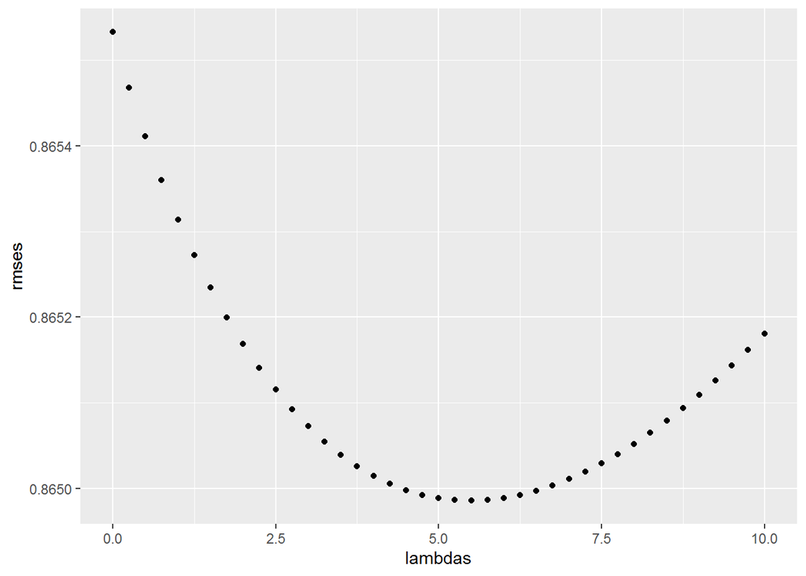

```r
qplot(lambdas, rmses)
```

We founded the 5.25 as the better value and then ran the prediction using this lambda. We compared the last method with the other calculations and, as the table shows, after predicting the regularized Movie and user effect model we got the minimum RMSE of 0.86.

## RMSE

```r
rmse_results %>% knitr::kable()
```

| method | RMSE |
| --- | --- |
| Just the average | 1.0606506 |
| Movie Effect Model | 0.9437046 |
| Movie + User Effects Model | 0.8655329 |
| Regularized Movie Effect Model | 0.9436740 |
| Regularized Movie + User Effect Model | 0.8649857 |